# Reproducible Research - CP #1

Marc-Antoine E.

15 avril 2016

R markdown document on first course project

Following analysis are based on data that can be downloaded at the following link: https://d396qusza40orc.cloudfront.net/repdata%2Fdata%2Factivity.zip

# Loading and preprocessing the data

Install requested packages if not found

```r
list.of.packages <- c("ggplot2", "dplyr", "lattice")
new.packages <- list.of.packages[!(list.of.packages %in% installed.packages()[,"Package"])]
if(length(new.packages)) install.packages(new.packages)
library(ggplot2)
library(dplyr)
library(lattice)
```

Unzip, read the data and store it in a new variable Overview of the new variable

```r
unzip("repdata-data-activity.zip")
activity <- read.csv(file = "activity.csv")
head(activity)
```

```
##   steps       date interval
## 1    NA 2012-10-01        0
## 2    NA 2012-10-01        5
## 3    NA 2012-10-01       10
## 4    NA 2012-10-01       15
## 5    NA 2012-10-01       20
## 6    NA 2012-10-01       25
```

# What is mean total number of steps taken per day?

Group by date

```r
activity_groupbyday <- data.frame(activity$date,activity$steps)
activity_groupbyday <- aggregate(activity_groupbyday$activity.steps, by=list(Date = activity_groupbyday$activity.date),FUN = sum )
names(activity_groupbyday) <- c("Date","Steps")
activity_groupbyday$ID <- as.numeric(rownames(activity_groupbyday))
activity_groupbyday <- activity_groupbyday[!is.na(activity_groupbyday$Steps),]
```

Print activity histogram

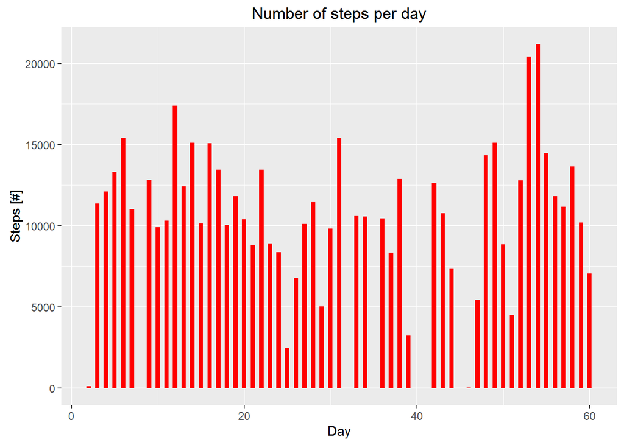

```r
ggplot(activity_groupbyday) + geom_histogram(aes(x=ID, weight = Steps), fill= "red", binwidth = 0.5) + ggtitle("Number of steps per day") + ylab("Steps [#]") + xlab("Day")
```

Calculate mean and median

```r
stat_activity <- c(mean(activity_groupbyday$Steps),median(activity_groupbyday$Steps))
names(stat_activity) <- c("Mean","Median")
stat_activity
```

```
##     Mean   Median
## 10766.19 10765.00
```

# What is the average daily activity pattern?

Average daily activity pattern

```r
daily_pattern <- tapply(activity$steps,activity$interval,FUN = mean, na.rm = TRUE)
head(daily_pattern)
```

```
##         0         5        10        15        20        25
## 1.7169811 0.3396226 0.1320755 0.1509434 0.0754717 2.0943396
```

Print daily activity pattern

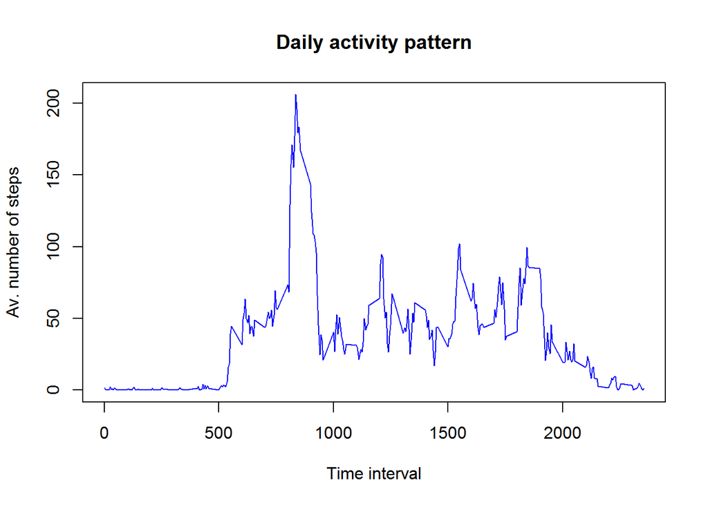

```r
plot(row.names(daily_pattern), daily_pattern, type = "l", xlab = "Time interval", ylab = "Av. number of steps", main = "Daily activity pattern", col = "blue")
```

5-minute interval, on average across all the days in the dataset, containing the maximum number of steps

```r
interval_max <- which.max(daily_pattern)
names(interval_max)
```

```
## [1] "835"
```

# Imputing missing values

Total number of missing values in the dataset (i.e. the total number of rows with NAs)

```r
number_NA <- sum(is.na(activity))
number_NA
```

```
## [1] 2304
```

Filling in all of the missing values in the dataset : mean for that 5-minute interval

```r
steps_new <- NULL
for (i in 1:nrow(activity)){
  if (is.na(activity[i,]$steps)){
    steps_new[i] <- daily_pattern[row.names(daily_pattern) == activity[i,]$interval]
  }
  else {
    steps_new[i] <- activity[i,]$steps
    }
}
head(steps_new)
```

```
## [1] 1.7169811 0.3396226 0.1320755 0.1509434 0.0754717 2.0943396
```

Create a new dataset that is equal to the original dataset but with the missing data filled in

```r
activity_new <- activity
activity_new$steps <- steps_new
head(activity_new)
```

```
##       steps       date interval
## 1 1.7169811 2012-10-01        0
## 2 0.3396226 2012-10-01        5
## 3 0.1320755 2012-10-01       10
## 4 0.1509434 2012-10-01       15
## 5 0.0754717 2012-10-01       20
## 6 2.0943396 2012-10-01       25
```

Group by date

```r
activity_groupbyday2 <- data.frame(activity_new$date,activity_new$steps)
head(activity_groupbyday2)
```

```
##   activity_new.date activity_new.steps
## 1        2012-10-01          1.7169811
## 2        2012-10-01          0.3396226
## 3        2012-10-01          0.1320755
## 4        2012-10-01          0.1509434
## 5        2012-10-01          0.0754717
## 6        2012-10-01          2.0943396
```

```r
activity_groupbyday2 <- aggregate(activity_groupbyday2$activity_new.steps, by=list(Date = activity_groupbyday2$activity_new.date),FUN = sum )
names(activity_groupbyday2) <- c("Date","Steps")
activity_groupbyday2$ID <- as.numeric(rownames(activity_groupbyday2))
```

Print activity histogram

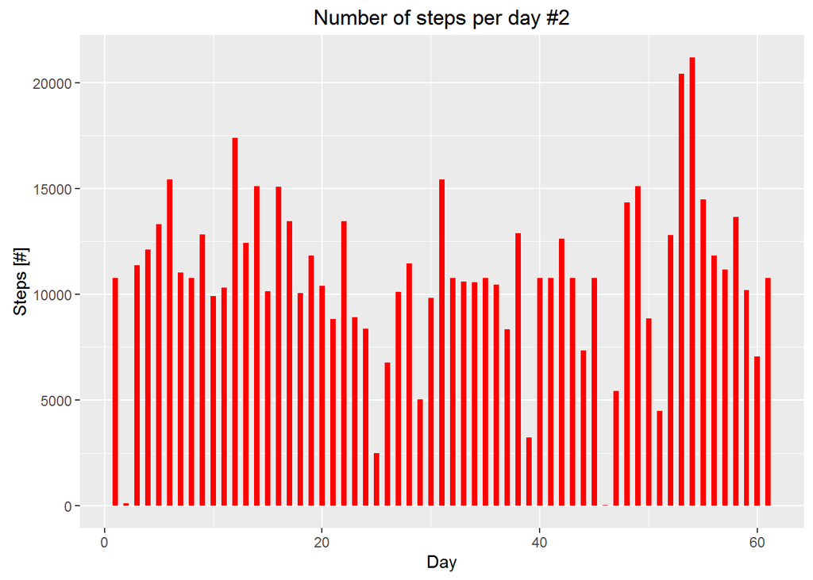

```r
ggplot(activity_groupbyday2) + geom_histogram(aes(x=ID, weight = Steps), fill= "red", binwidth = 0.5) + ggtitle("Number of steps per day #2") + ylab("Steps [#]") + xlab("Day")
```

Calculate mean and median

```r
stat_activity2 <- c(mean(activity_groupbyday2$Steps),median(activity_groupbyday2$Steps))
names(stat_activity2) <- c("Mean","Median")
stat_activity2
```

```
##     Mean   Median
## 10766.19 10766.19
```

# Are there differences in activity patterns between weekdays and weekends?

Creating a new factor variable in the dataset with two levels - “weekday” and “weekend” indicating whether a given date is a weekday or weekend day

```r
for (i in 1:nrow(activity_new)){
  if ((weekdays(as.Date(activity_new$date[i])) == "dimanche"||weekdays(as.Date(activity_new$date[i])) == "samedi")){
    activity_new$week[i] <- "weekend"
  }
  else {
    activity_new$week[i] <- "weekday"
  }
}
head(activity_new)
```

```
##       steps       date interval    week
## 1 1.7169811 2012-10-01        0 weekday
## 2 0.3396226 2012-10-01        5 weekday
## 3 0.1320755 2012-10-01       10 weekday
## 4 0.1509434 2012-10-01       15 weekday
## 5 0.0754717 2012-10-01       20 weekday
## 6 2.0943396 2012-10-01       25 weekday
```

Group by weekday and interval

```r
extract_activity <- aggregate(activity_new$steps, by =list(activity_new$interval, activity_new$week), data = activity_new,FUN = mean)
names(extract_activity) <- c("Interval","Week", "Steps")
```

Make a panel plot

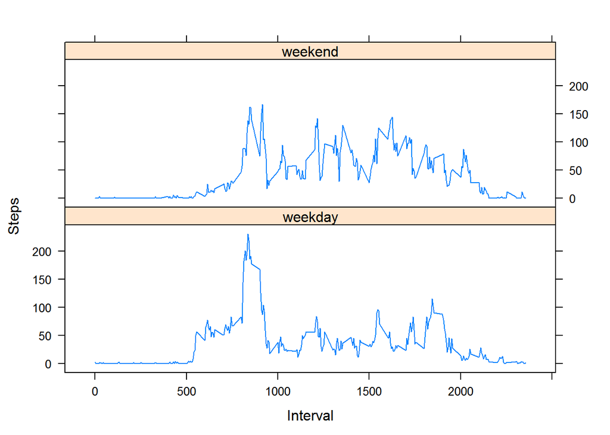

```r
xyplot(Steps ~ Interval | Week, extract_activity, type = "l", layout = c(1,2), xlab = "Interval", ylab = "Steps")
```